# assg 2

```python
import pandas as pd
```

```python
df = pd.read_csv(r'C:\Users\Admin\OneDrive - vit solutions\Desktop\python\car_crashes.csv')
```

```python
df
```

|  | total | speeding | alcohol | not_distracted | no_previous | ins_premium | ins_losses | abbrev |
| --- | --- | --- | --- | --- | --- | --- | --- | --- |
| 0 | 18.8 | 7.332 | 5.640 | 18.048 | 15.040 | 784.55 | 145.08 | AL |
| 1 | 18.1 | 7.421 | 4.525 | 16.290 | 17.014 | 1053.48 | 133.93 | AK |
| 2 | 18.6 | 6.510 | 5.208 | 15.624 | 17.856 | 899.47 | 110.35 | AZ |
| 3 | 22.4 | 4.032 | 5.824 | 21.056 | 21.280 | 827.34 | 142.39 | AR |
| 4 | 12.0 | 4.200 | 3.360 | 10.920 | 10.680 | 878.41 | 165.63 | CA |
| 5 | 13.6 | 5.032 | 3.808 | 10.744 | 12.920 | 835.50 | 139.91 | CO |
| 6 | 10.8 | 4.968 | 3.888 | 9.396 | 8.856 | 1068.73 | 167.02 | CT |
| 7 | 16.2 | 6.156 | 4.860 | 14.094 | 16.038 | 1137.87 | 151.48 | DE |
| 8 | 5.9 | 2.006 | 1.593 | 5.900 | 5.900 | 1273.89 | 136.05 | DC |
| 9 | 17.9 | 3.759 | 5.191 | 16.468 | 16.826 | 1160.13 | 144.18 | FL |
| 10 | 15.6 | 2.964 | 3.900 | 14.820 | 14.508 | 913.15 | 142.80 | GA |
| 11 | 17.5 | 9.450 | 7.175 | 14.350 | 15.225 | 861.18 | 120.92 | HI |
| 12 | 15.3 | 5.508 | 4.437 | 13.005 | 14.994 | 641.96 | 82.75 | ID |
| 13 | 12.8 | 4.608 | 4.352 | 12.032 | 12.288 | 803.11 | 139.15 | IL |
| 14 | 14.5 | 3.625 | 4.205 | 13.775 | 13.775 | 710.46 | 108.92 | IN |
| 15 | 15.7 | 2.669 | 3.925 | 15.229 | 13.659 | 649.06 | 114.47 | IA |
| 16 | 17.8 | 4.806 | 4.272 | 13.706 | 15.130 | 780.45 | 133.80 | KS |
| 17 | 21.4 | 4.066 | 4.922 | 16.692 | 16.264 | 872.51 | 137.13 | KY |
| 18 | 20.5 | 7.175 | 6.765 | 14.965 | 20.090 | 1281.55 | 194.78 | LA |
| 19 | 15.1 | 5.738 | 4.530 | 13.137 | 12.684 | 661.88 | 96.57 | ME |
| 20 | 12.5 | 4.250 | 4.000 | 8.875 | 12.375 | 1048.78 | 192.70 | MD |
| 21 | 8.2 | 1.886 | 2.870 | 7.134 | 6.560 | 1011.14 | 135.63 | MA |
| 22 | 14.1 | 3.384 | 3.948 | 13.395 | 10.857 | 1110.61 | 152.26 | MI |
| 23 | 9.6 | 2.208 | 2.784 | 8.448 | 8.448 | 777.18 | 133.35 | MN |
| 24 | 17.6 | 2.640 | 5.456 | 1.760 | 17.600 | 896.07 | 155.77 | MS |
| 25 | 16.1 | 6.923 | 5.474 | 14.812 | 13.524 | 790.32 | 144.45 | MO |
| 26 | 21.4 | 8.346 | 9.416 | 17.976 | 18.190 | 816.21 | 85.15 | MT |
| 27 | 14.9 | 1.937 | 5.215 | 13.857 | 13.410 | 732.28 | 114.82 | NE |
| 28 | 14.7 | 5.439 | 4.704 | 13.965 | 14.553 | 1029.87 | 138.71 | NV |
| 29 | 11.6 | 4.060 | 3.480 | 10.092 | 9.628 | 746.54 | 120.21 | NH |
| 30 | 11.2 | 1.792 | 3.136 | 9.632 | 8.736 | 1301.52 | 159.85 | NJ |
| 31 | 18.4 | 3.496 | 4.968 | 12.328 | 18.032 | 869.85 | 120.75 | NM |
| 32 | 12.3 | 3.936 | 3.567 | 10.824 | 9.840 | 1234.31 | 150.01 | NY |
| 33 | 16.8 | 6.552 | 5.208 | 15.792 | 13.608 | 708.24 | 127.82 | NC |
| 34 | 23.9 | 5.497 | 10.038 | 23.661 | 20.554 | 688.75 | 109.72 | ND |
| 35 | 14.1 | 3.948 | 4.794 | 13.959 | 11.562 | 697.73 | 133.52 | OH |
| 36 | 19.9 | 6.368 | 5.771 | 18.308 | 18.706 | 881.51 | 178.86 | OK |
| 37 | 12.8 | 4.224 | 3.328 | 8.576 | 11.520 | 804.71 | 104.61 | OR |
| 38 | 18.2 | 9.100 | 5.642 | 17.472 | 16.016 | 905.99 | 153.86 | PA |
| 39 | 11.1 | 3.774 | 4.218 | 10.212 | 8.769 | 1148.99 | 148.58 | RI |
| 40 | 23.9 | 9.082 | 9.799 | 22.944 | 19.359 | 858.97 | 116.29 | SC |
| 41 | 19.4 | 6.014 | 6.402 | 19.012 | 16.684 | 669.31 | 96.87 | SD |
| 42 | 19.5 | 4.095 | 5.655 | 15.990 | 15.795 | 767.91 | 155.57 | TN |
| 43 | 19.4 | 7.760 | 7.372 | 17.654 | 16.878 | 1004.75 | 156.83 | TX |
| 44 | 11.3 | 4.859 | 1.808 | 9.944 | 10.848 | 809.38 | 109.48 | UT |
| 45 | 13.6 | 4.080 | 4.080 | 13.056 | 12.920 | 716.20 | 109.61 | VT |
| 46 | 12.7 | 2.413 | 3.429 | 11.049 | 11.176 | 768.95 | 153.72 | VA |
| 47 | 10.6 | 4.452 | 3.498 | 8.692 | 9.116 | 890.03 | 111.62 | WA |
| 48 | 23.8 | 8.092 | 6.664 | 23.086 | 20.706 | 992.61 | 152.56 | WV |
| 49 | 13.8 | 4.968 | 4.554 | 5.382 | 11.592 | 670.31 | 106.62 | WI |
| 50 | 17.4 | 7.308 | 5.568 | 14.094 | 15.660 | 791.14 | 122.04 | WY |

```python
import numpy as np
import pandas as pd
import matplotlib.pyplot as plt
```

```python
df.head()
```

|  | total | speeding | alcohol | not_distracted | no_previous | ins_premium | ins_losses | abbrev |
| --- | --- | --- | --- | --- | --- | --- | --- | --- |
| 0 | 18.8 | 7.332 | 5.640 | 18.048 | 15.040 | 784.55 | 145.08 | AL |
| 1 | 18.1 | 7.421 | 4.525 | 16.290 | 17.014 | 1053.48 | 133.93 | AK |
| 2 | 18.6 | 6.510 | 5.208 | 15.624 | 17.856 | 899.47 | 110.35 | AZ |
| 3 | 22.4 | 4.032 | 5.824 | 21.056 | 21.280 | 827.34 | 142.39 | AR |
| 4 | 12.0 | 4.200 | 3.360 | 10.920 | 10.680 | 878.41 | 165.63 | CA |

```python
df.tail()
```

|  | total | speeding | alcohol | not_distracted | no_previous | ins_premium | ins_losses | abbrev |
| --- | --- | --- | --- | --- | --- | --- | --- | --- |
| 46 | 12.7 | 2.413 | 3.429 | 11.049 | 11.176 | 768.95 | 153.72 | VA |
| 47 | 10.6 | 4.452 | 3.498 | 8.692 | 9.116 | 890.03 | 111.62 | WA |
| 48 | 23.8 | 8.092 | 6.664 | 23.086 | 20.706 | 992.61 | 152.56 | WV |
| 49 | 13.8 | 4.968 | 4.554 | 5.382 | 11.592 | 670.31 | 106.62 | WI |
| 50 | 17.4 | 7.308 | 5.568 | 14.094 | 15.660 | 791.14 | 122.04 | WY |

```python
df.describe()
```

|  | total | speeding | alcohol | not_distracted | no_previous | ins_premium | ins_losses |
| --- | --- | --- | --- | --- | --- | --- | --- |
| count | 51.000000 | 51.000000 | 51.000000 | 51.000000 | 51.000000 | 51.000000 | 51.000000 |
| mean | 15.790196 | 4.998196 | 4.886784 | 13.573176 | 14.004882 | 886.957647 | 134.493137 |
| std | 4.122002 | 2.017747 | 1.729133 | 4.508977 | 3.764672 | 178.296285 | 24.835922 |
| min | 5.900000 | 1.792000 | 1.593000 | 1.760000 | 5.900000 | 641.960000 | 82.750000 |
| 25% | 12.750000 | 3.766500 | 3.894000 | 10.478000 | 11.348000 | 768.430000 | 114.645000 |
| 50% | 15.600000 | 4.608000 | 4.554000 | 13.857000 | 13.775000 | 858.970000 | 136.050000 |
| 75% | 18.500000 | 6.439000 | 5.604000 | 16.140000 | 16.755000 | 1007.945000 | 151.870000 |
| max | 23.900000 | 9.450000 | 10.038000 | 23.661000 | 21.280000 | 1301.520000 | 194.780000 |

```python
corr=df.corr()
corr
```

|  | total | speeding | alcohol | not_distracted | no_previous | ins_premium | ins_losses |
| --- | --- | --- | --- | --- | --- | --- | --- |
| total | 1.000000 | 0.611548 | 0.852613 | 0.827560 | 0.956179 | -0.199702 | -0.036011 |
| speeding | 0.611548 | 1.000000 | 0.669719 | 0.588010 | 0.571976 | -0.077675 | -0.065928 |
| alcohol | 0.852613 | 0.669719 | 1.000000 | 0.732816 | 0.783520 | -0.170612 | -0.112547 |
| not_distracted | 0.827560 | 0.588010 | 0.732816 | 1.000000 | 0.747307 | -0.174856 | -0.075970 |
| no_previous | 0.956179 | 0.571976 | 0.783520 | 0.747307 | 1.000000 | -0.156895 | -0.006359 |
| ins_premium | -0.199702 | -0.077675 | -0.170612 | -0.174856 | -0.156895 | 1.000000 | 0.623116 |
| ins_losses | -0.036011 | -0.065928 | -0.112547 | -0.075970 | -0.006359 | 0.623116 | 1.000000 |

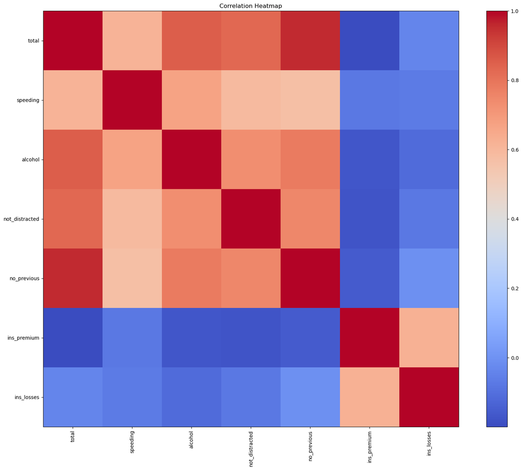

```python
plt.figure(figsize=(20, 15))
plt.imshow(corr, cmap='coolwarm', interpolation='nearest')
plt.colorbar()
plt.xticks(range(len(corr.columns)), corr.columns, rotation=90)
plt.yticks(range(len(corr.columns)), corr.columns)
plt.title('Correlation Heatmap')
plt.show()
```

inference: We can observe that,as the speed of the cars increases the crashes increases.

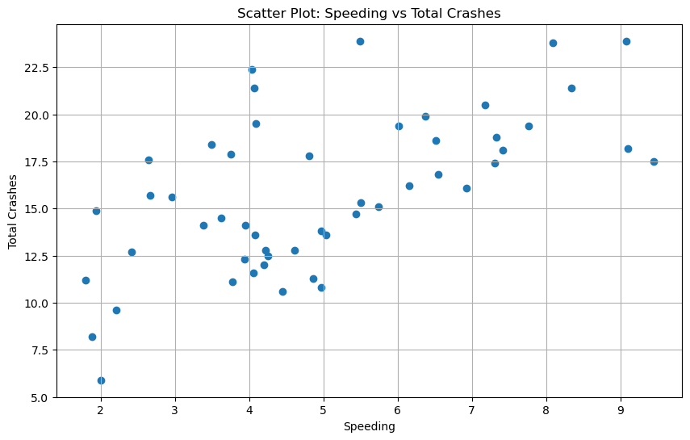

```python
plt.figure(figsize=(10, 6))
plt.scatter(df['speeding'], df['total'])
plt.xlabel('Speeding')
plt.ylabel('Total Crashes')
plt.title('Scatter Plot: Speeding vs Total Crashes')
plt.grid(True)
plt.show()
```

Inference: As we can observe it is a positive correlation ,if the speeding increases the total no of crashes increases it may have positive strong relation ship

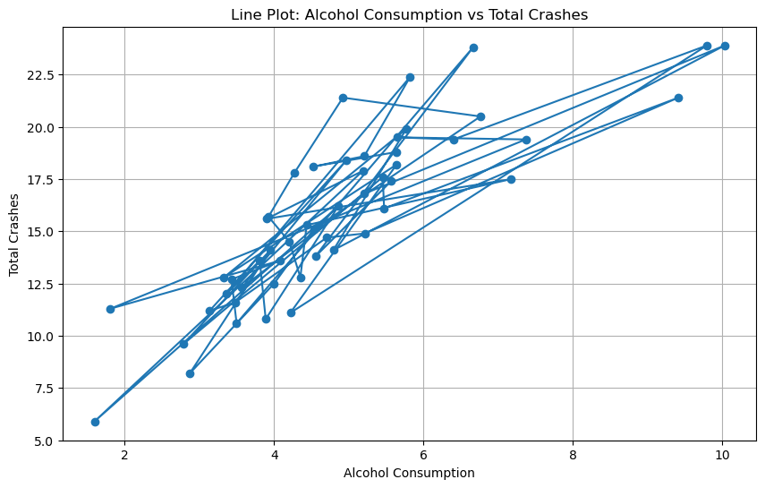

```python
plt.figure(figsize=(10, 6))
plt.plot(df['alcohol'], df['total'], marker='o', linestyle='-')
plt.xlabel('Alcohol Consumption')
plt.ylabel('Total Crashes')
plt.title('Line Plot: Alcohol Consumption vs Total Crashes')
plt.grid(True)
plt.show()
```

Inference: we can observe that line slopes upward from left to right, it indicates a positive relationship between alcohol involvement and car crashes.

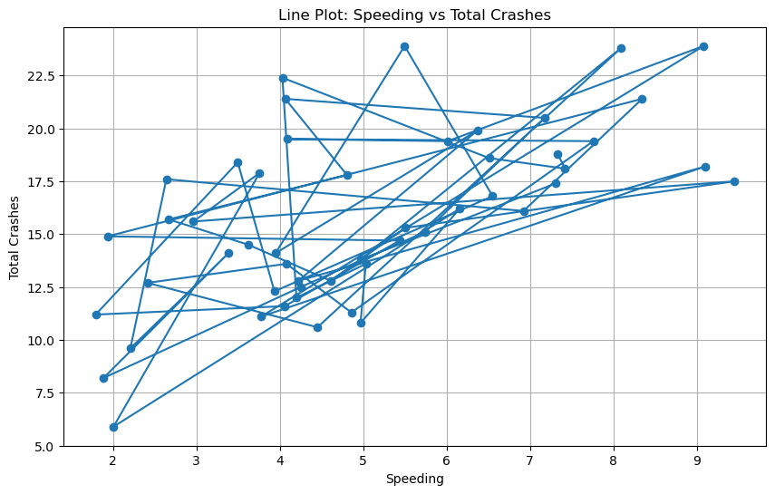

```python
plt.figure(figsize=(10, 6))
plt.plot(df['speeding'], df['total'], marker='o', linestyle='-')
plt.xlabel('Speeding')
plt.ylabel('Total Crashes')
plt.title('Line Plot: Speeding vs Total Crashes')
plt.grid(True)
plt.show()
```

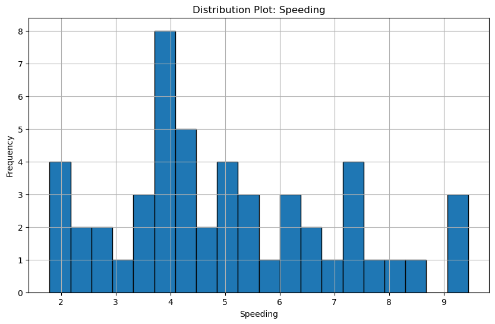

```python
plt.figure(figsize=(10, 6))
plt.hist(df['speeding'], bins=20, edgecolor='k')
plt.xlabel('Speeding')
plt.ylabel('Frequency')
plt.title('Distribution Plot: Speeding')
plt.grid(True)
plt.show()
```

Inference: The distplot shows that majority of the states speeding levels are average .

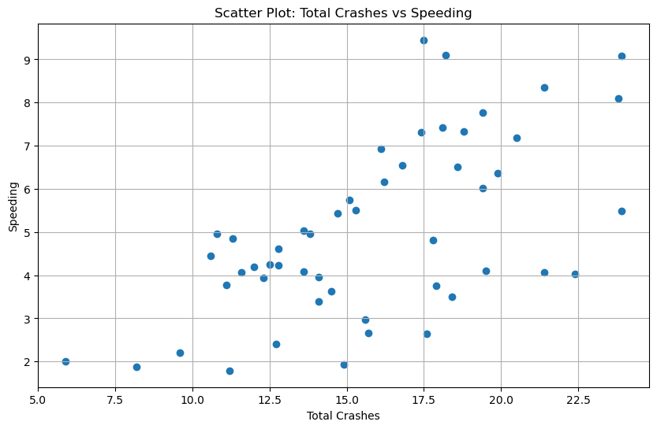

```python
plt.figure(figsize=(10, 6))
plt.scatter(df['total'], df['speeding'])
plt.xlabel('Total Crashes')
plt.ylabel('Speeding')
plt.title('Scatter Plot: Total Crashes vs Speeding')
plt.grid(True)
plt.show()
```

```python
df["ins_losses"].value_counts()
```

[output not shown]

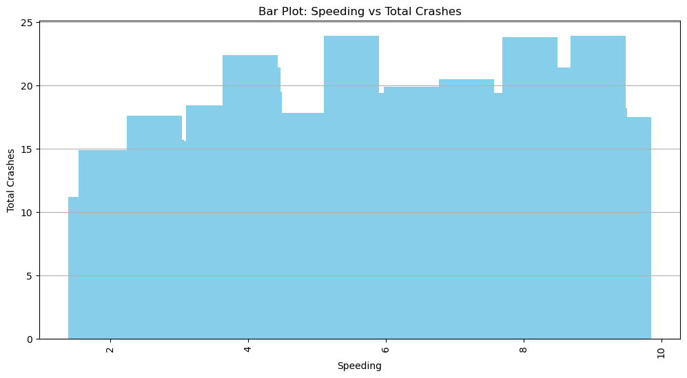

```python
# Assuming 'df' is your DataFrame containing the dataset
plt.figure(figsize=(12, 6))
plt.bar(df['speeding'], df['total'], color='skyblue')
plt.xlabel('Speeding')
plt.ylabel('Total Crashes')
plt.title('Bar Plot: Speeding vs Total Crashes')
plt.xticks(rotation=90)  # Rotate x-axis labels if needed
plt.grid(axis='y')
plt.show()
```

Inference: The graph shows the relationship b/w the total number of car crashes and the speeding level of the cars.

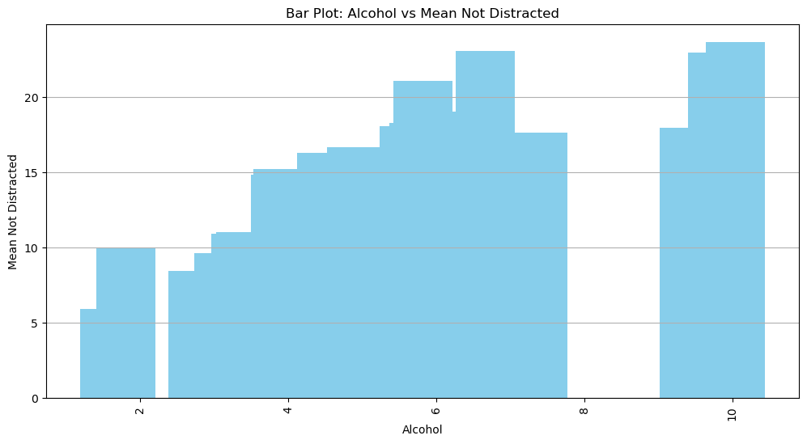

```python
# Assuming 'df' is your DataFrame containing the dataset
plt.figure(figsize=(12, 6))
grouped_data = df.groupby('alcohol')['not_distracted'].mean().reset_index()
plt.bar(grouped_data['alcohol'], grouped_data['not_distracted'], color='skyblue')
plt.xlabel('Alcohol')
plt.ylabel('Mean Not Distracted')
plt.title('Bar Plot: Alcohol vs Mean Not Distracted')
plt.xticks(rotation=90)  # Rotate x-axis labels if needed
plt.grid(axis='y')
plt.show()
```

Inference: The barplot shows that consumption of alcohol relationship b/w the not distracted the, highest rate of consumption of alcohol and not distracted is plotted in the graph

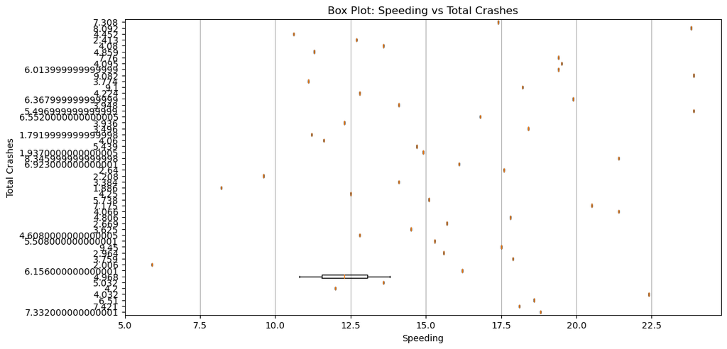

```python
plt.figure(figsize=(12, 6))
box_data = [df[df['speeding'] == category]['total'] for category in df['speeding'].unique()]
plt.boxplot(box_data, labels=df['speeding'].unique(), vert=False)
plt.xlabel('Speeding')
plt.ylabel('Total Crashes')
plt.title('Box Plot: Speeding vs Total Crashes')
plt.grid(axis='x')
plt.show()
```

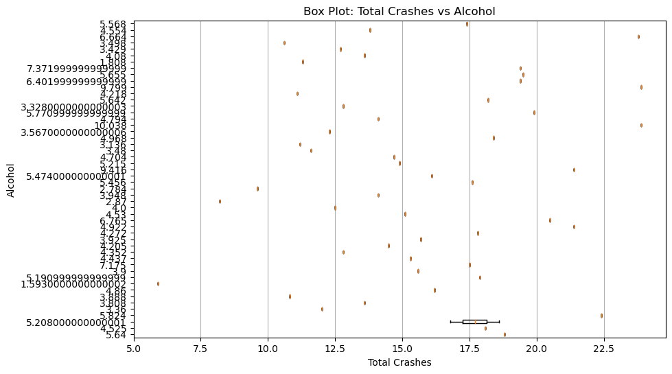

```python
plt.figure(figsize=(10, 6))
plt.boxplot([df[df['alcohol'] == category]['total'] for category in df['alcohol'].unique()],
            labels=df['alcohol'].unique(), vert=False)
plt.xlabel('Total Crashes')
plt.ylabel('Alcohol')
plt.title('Box Plot: Total Crashes vs Alcohol')
plt.grid(axis='x')
plt.show()
```

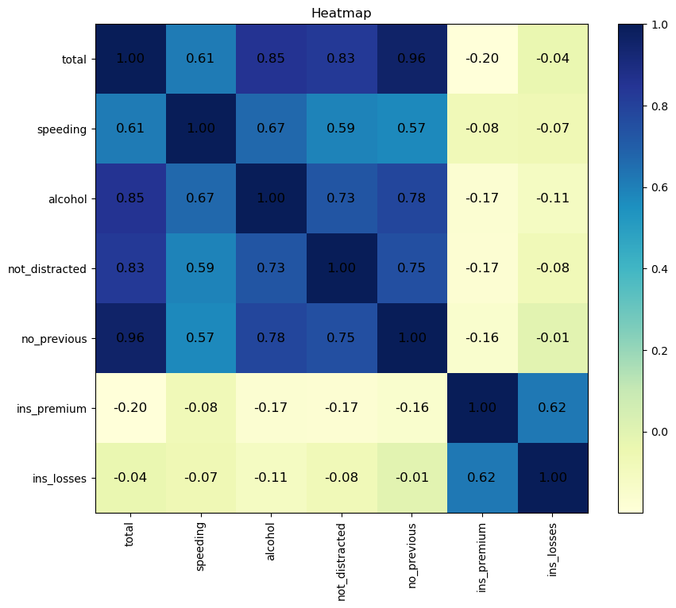

```python
# Assuming 'corr' is your correlation matrix
plt.figure(figsize=(10, 8))
heatmap = plt.imshow(corr, cmap='YlGnBu', aspect='auto')

plt.colorbar(heatmap)
plt.title('Heatmap')
plt.xticks(range(len(corr.columns)), corr.columns, rotation=90)
plt.yticks(range(len(corr.columns)), corr.columns)

# Annotate the heatmap cells with correlation values
for i in range(len(corr.columns)):
    for j in range(len(corr.columns)):
        plt.text(j, i, f'{corr.values[i, j]:.2f}', ha='center', va='center', fontsize=12, color='black')

plt.show()
```

Inference: The heatmap visualizes the correlation between numerical variables

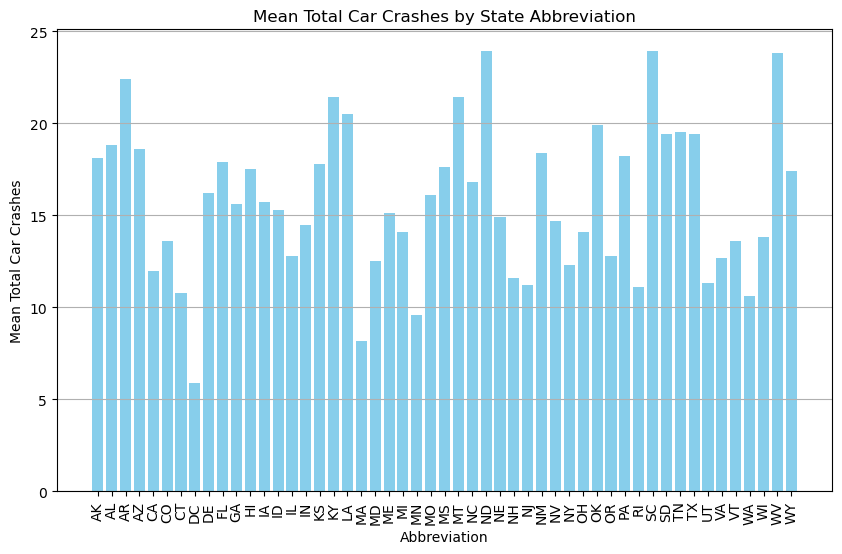

```python
import pandas as pd
import matplotlib.pyplot as plt

# Load the dataset from the specified path
file_path = r"C:\Users\Admin\OneDrive - vit solutions\Desktop\python\car_crashes.csv"
car_crashes = pd.read_csv(file_path)

plt.figure(figsize=(10, 6))
car_crashes_grouped = car_crashes.groupby('abbrev')['total'].mean().reset_index()
plt.bar(car_crashes_grouped['abbrev'], car_crashes_grouped['total'], color='skyblue')
plt.xlabel('Abbreviation')
plt.ylabel('Mean Total Car Crashes')
plt.title('Mean Total Car Crashes by State Abbreviation')
plt.xticks(rotation=90)
plt.grid(axis='y')
plt.show()
```

Inference: By the graph we can observe that , the total number of crashes in each state ,the highest number of crashes are observed in three states i.e..ND,SC,WV.

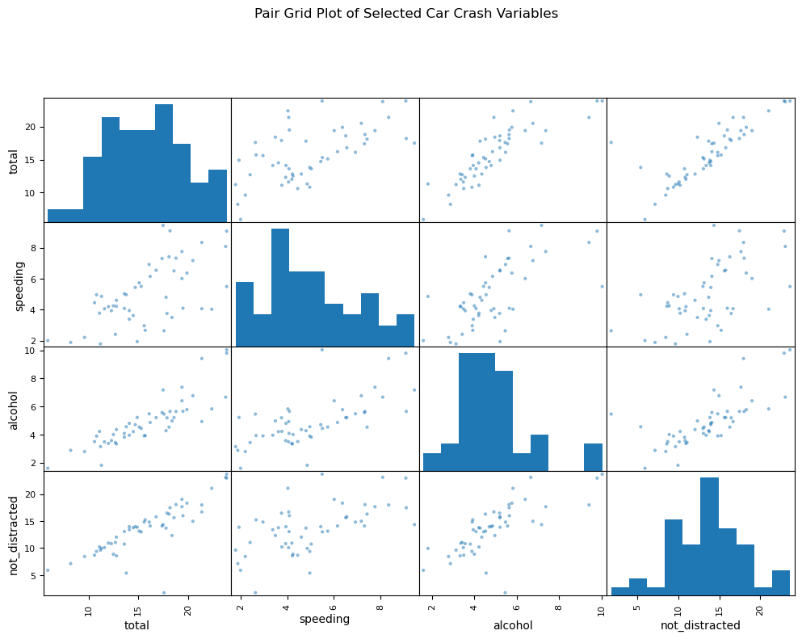

```python
import pandas as pd
import matplotlib.pyplot as plt
import seaborn as sns

# Load the dataset from the specified path
file_path = r"C:\Users\Admin\OneDrive - vit solutions\Desktop\python\car_crashes.csv"
car_crashes = pd.read_csv(file_path)

selected_columns = ['total', 'speeding', 'alcohol', 'not_distracted']
pair_grid = pd.plotting.scatter_matrix(car_crashes[selected_columns], figsize=(12, 8))

# Set individual subplot titles
for ax in pair_grid.ravel():
    ax.set_title('')

# Set a common title for the pair grid plot
plt.suptitle('Pair Grid Plot of Selected Car Crash Variables', y=1.02)
plt.show()
```